# Praca domowa 2

Maciej Pastuszka

## Dane

Dane wykorzystane w Pracy domowej 2 dotyczą wyników egzaminów z 3 umiejętności: czytania, pisania i operacji matematycznych. Dodatkowo dostępne są podstawowe informacje o studentach i ich rodzicach. Opis wszystkich kolumn znajduje się również w pliku `README.md`.

| Zmienna | Opis |
| --- | --- |
| **gender** | płeć |
| **race.ethnicity** | pochodzenie etniczne |
| **parental.level.of.education** | wykształcenie rodziców |
| **lunch** | jaki obiad jedli uczniowie w dniu egzaminu |
| **test.preparation.course** | czy uczeń odbył kurs przygotowujący |
| **math.score** | wynik egzaminu z matematyki |
| **reading.score** | wynik egzaminu z czytania |
| **writing.score** | wynik egzaminu z pisania |

## Zadanie 1

Jak wyglądają rozkłady wyników uczniów z trzech przedmiotów (matematyka, czytanie, pisanie)?

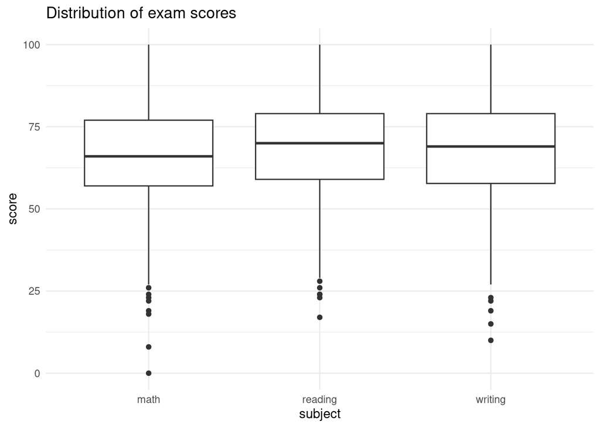

```r
data1 <- df %>%
  # dla czytelnosci
  rename(math=math.score,
         reading=reading.score,
         writing=writing.score) %>%
  pivot_longer(
    cols = c(math, reading, writing),
    names_to = "subject",
    values_to = "score"
  )

plot1 <- ggplot(data1, aes(x = subject, y = score)) +
  geom_boxplot() +
  theme_minimal() +
  labs(title="Distribution of exam scores")

plot1
```

**Komentarz: Czytanie ma najwyzsza mediane wynikow (gruba linia w srodku pudelka), przecietnie uczniowie sobie radzili najlepiej z tym przedmiotem, podobne wyniki uczniowie uzyskali z pisania (podobna wysokosc pudelka, lecz mniejsza mediana), najgorzej uczniom poszedł egzamin z matematyki, pudleko jest wyraźnie niżej, oraz wartości odstające na dole są też gorsze niż dla pozostałych egzaminóœ**

## Zadanie 2

Czy istnieje zauważalna różnica w wynikach między uczniami i uczennicami?

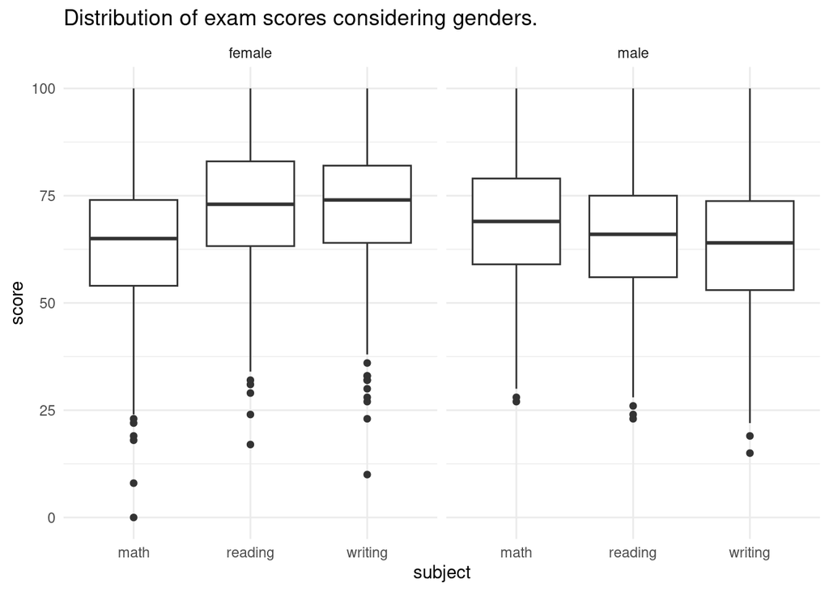

```r
# Tu umieść kod do wygenerowania odpowiedzi do zadania.
# skorzystam z danych z poprzedniego zadania
data2 <- data1
plot2 <- ggplot(data2, aes(x=subject, y=score)) +
  geom_boxplot() +
  facet_wrap(~gender) +
  labs(title="Distribution of exam scores considering genders.") +
  theme_minimal()

plot2
```

**Komentarz: Na wykresie istnieje zauważalna różnica między wynikami uczennic, a wynikami uczniów. Widzimy, że mediany wyników z czytania i pisania, są wyższe dla uczennic niż dla uczniów, z drugiej strony mediana wyników z matematyki jes wyższa w grupie chłopców.**

## Zadanie 3

Czy uczniowie, którzy ukończyli kurs przygotowawczy, osiągają lepsze wyniki niż pozostali?

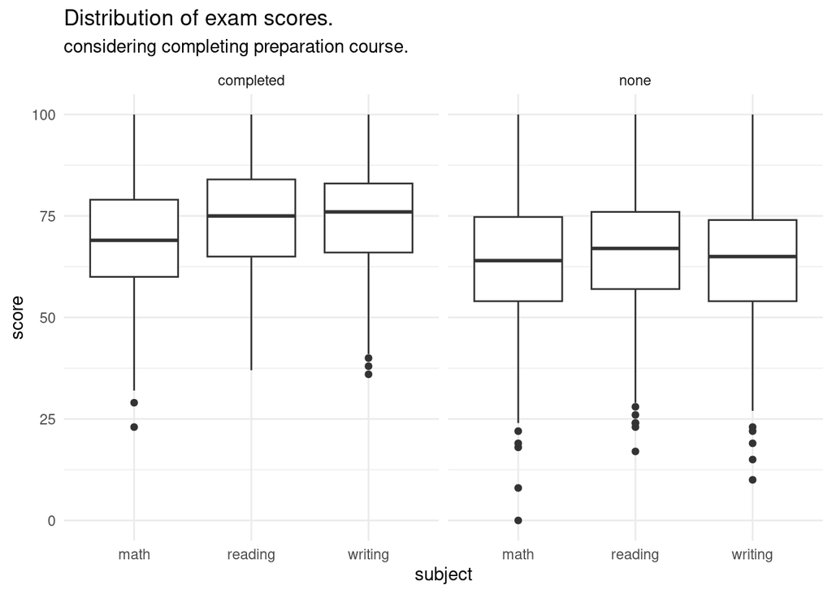

```r
# Tu umieść kod do wygenerowania odpowiedzi do zadania.
data3 <- data1

plot3 <- ggplot(data3,aes(x=subject,y=score)) +
  facet_wrap(~test.preparation.course) +
  geom_boxplot() +
  labs(title="Distribution of exam scores.",
       subtitle="considering completing preparation course.") +
  theme_minimal()


plot3
```

**Komentarz:Tak, uczniowie, którzy ukończyli kurs przygotowawczy osiągają lepsze wyniki, ze wszystkich przedmiotow, mediany sa wyzsze dla wszystkich. W grupie uczniow, ktorzy ukonczyli kurs widac mniej wartosci odstajacych, ktore nieliczne sa i tak wieksze od niektorych bardzo niskich wynikow w grupie uczniów, którzy nie ukończyli kursu.**

## Zadanie 4

Jaki jest związek między poziomem wykształcenia rodziców a średnimi wynikami uczniów?

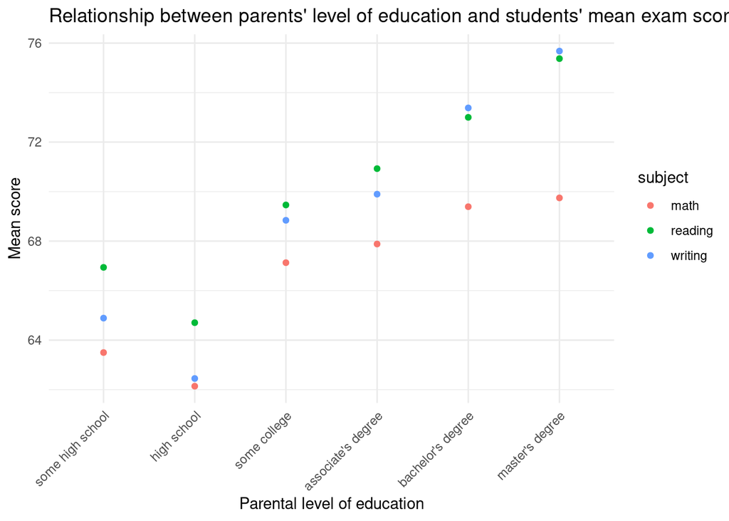

```r
# Tu umieść kod do wygenerowania odpowiedzi do zadania.
data4 <- data1 %>%
  group_by(parental.level.of.education, subject) %>%
  summarise(mean.score = mean(score))

# kolejnosc w jakiej stopnie beda na wykresie
order_of_advancement <- c("some high school", "high school",
                         "some college", "associate's degree",
                         "bachelor's degree", "master's degree")

data4$parental.level.of.education <- factor(data4$parental.level.of.education,
                                      levels=order_of_advancement)

plot4 <- ggplot(data4, aes(x=parental.level.of.education,
                  y=mean.score,
                  color=subject)) +
  geom_point() +
  theme_minimal() +
  theme(axis.text.x = element_text(angle=45, hjust=1)) +
  labs(title="Relationship between parents' level of education and students' mean exam scores",
       x="Parental level of education",
       y="Mean score")

plot4
```

**Komentarz: Na wykresie oś x jest uszeregowana zgodnie z zaawansowaniem stopni edukacji rodziców. Widać, że nie licząc dwóch najniższych stopnii, tzn. nieukończonej szkoły średniej(some high school) i ukończonej (high school) (ciekawe odstępstwo), im lepiej wyedukowani rodzice, tym dzieci osiągają lepsze średnie wyniki ze wszystkich egzaminów.**

## Zadanie 5

Czy płeć i wykształcenie rodzica wpływa na wynik z matematyki?

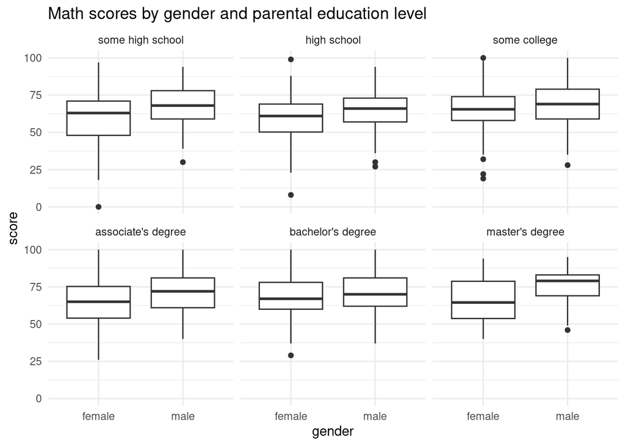

```r
# Tu umieść kod do wygenerowania odpowiedzi do zadania.
data5 <- data1 %>%
  filter(subject == "math")

order_of_advancement <- c("some high school", "high school",
                         "some college", "associate's degree",
                         "bachelor's degree", "master's degree")

data5$parental.level.of.education <- factor(data5$parental.level.of.education,
                                      levels=order_of_advancement)

plot5 <- ggplot(data5, aes(x=gender, y=score)) +
  facet_wrap(~parental.level.of.education) +
  geom_boxplot() +
  labs(title="Math scores by gender and parental education level") +
  theme_minimal()


plot5
```

## Zadanie 6

Czy istnieje zależność między wynikami z matematyki a wynikami z czytania lub pisania?

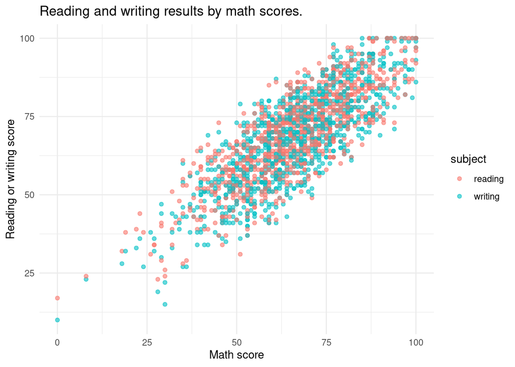

```r
# Tu umieść kod do wygenerowania odpowiedzi do zadania.

data6 <- df %>%
  rename(writing = writing.score,
         reading = reading.score) %>%
  pivot_longer(
    cols = c(writing, reading),
    names_to = "subject",
    values_to = "score"
  )

plot6 <- ggplot(data6, aes(x=math.score, y=score, color = subject)) +
  geom_point(alpha=0.6) +
  labs(title="Reading and writing results by math scores.",
       x="Math score",
       y="Reading or writing score") +
  theme_minimal()

plot6
```

**Komentarz: Widać, że im wyższe wyniki z matematyki, tym wyższe wyniki z egzaminów z czytania i pisania.**